# PBMC_granulocyte_sc_ATAC_RNA_Seurat_Signac

Devika Agarwal

Last update: Wed Jun 2 16:03:13 2021

```r
library(Signac)
library(Seurat)
library(EnsDb.Hsapiens.v86)
library(BSgenome.Hsapiens.UCSC.hg38)
library(tidyverse)
library(patchwork)
library(data.table)
library(doMC)
knitr::opts_chunk$set(cache=F,echo=T,message=FALSE,warning=FALSE, cache.lazy = FALSE)
## white background theme for all
theme_set(theme_bw())
set.seed(76034)
```

# 1 Load RNA and ATAC data

```r
# load the RNA and ATAC data
counts <- Read10X_h5("./pbmc_granulocyte_sorted_3k_filtered_feature_bc_matrix.h5")
```

```
'giveCsparse' has been deprecated; setting 'repr = "T"' for youGenome matrix has multiple modalities, returning a list of matrices for this genome
```

```r
fragpath <- "./pbmc_granulocyte_sorted_3k_atac_fragments.tsv.gz"
```

# 2 Get gene annotations and create seurat object for RNA and ATAC assay

```r
# get gene annotations for hg38
annotation <- GetGRangesFromEnsDb(ensdb = EnsDb.Hsapiens.v86)
```

[output not shown]

[output cut: 145 more lines]

[output not shown]

```r
seqlevelsStyle(annotation) <- "UCSC"
genome(annotation) <- "hg38"




# create a Seurat object containing the RNA adata
pbmc <- CreateSeuratObject(
  counts = counts$`Gene Expression`,
  assay = "RNA"
)
pbmc[["percent.mt"]] <- PercentageFeatureSet(pbmc, pattern = "^MT-")

# create ATAC assay and add it to the object
pbmc[["ATAC"]] <- CreateChromatinAssay(
  counts = counts$Peaks,
  sep = c(":", "-"),
  fragments = fragpath,
  annotation = annotation,
  min.cells = 10
)
```

```
Computing hash
Checking for 2711 cell barcodes
```

```r
pbmc
```

```
An object of class Seurat
134680 features across 2711 samples within 2 assays
Active assay: RNA (36601 features, 0 variable features)
 1 other assay present: ATAC
```

```r
pbmc[['ATAC']]
```

```
ChromatinAssay data with 98079 features for 2711 cells
Variable features: 0
Genome:
Annotation present: TRUE
Motifs present: FALSE
Fragment files: 1
```

# 3 Quality Control

We can compute per-cell quality control metrics using the DNA accessibility data and remove cells that are outliers for these metrics, as well as cells with low or unusually high counts for either the RNA or ATAC assay.

```r
DefaultAssay(pbmc) <- "ATAC"

pbmc <- NucleosomeSignal(pbmc)
```

[output not shown]

```r
pbmc <- TSSEnrichment(pbmc, fast=FALSE)
```

```
Extracting TSS positions
Finding + strand cut sites
Finding - strand cut sites
Computing mean insertion frequency in flanking regions
Normalizing TSS score
```

We can inspect the TSS enrichment scores by grouping the cells based on the score and plotting the accessibility signal over all TSS sites. Setting the fast=TRUE option in TSSEnrichment() will only compute the TSS enrichment score without storing the entire cell by position matrix of Tn5 insertion frequency for each cell, and can save memory. However, setting fast=TRUE will not allow downstream plotting of the TSS enrichment signal for different groups of cells using the TSSPlot() function, shown here:

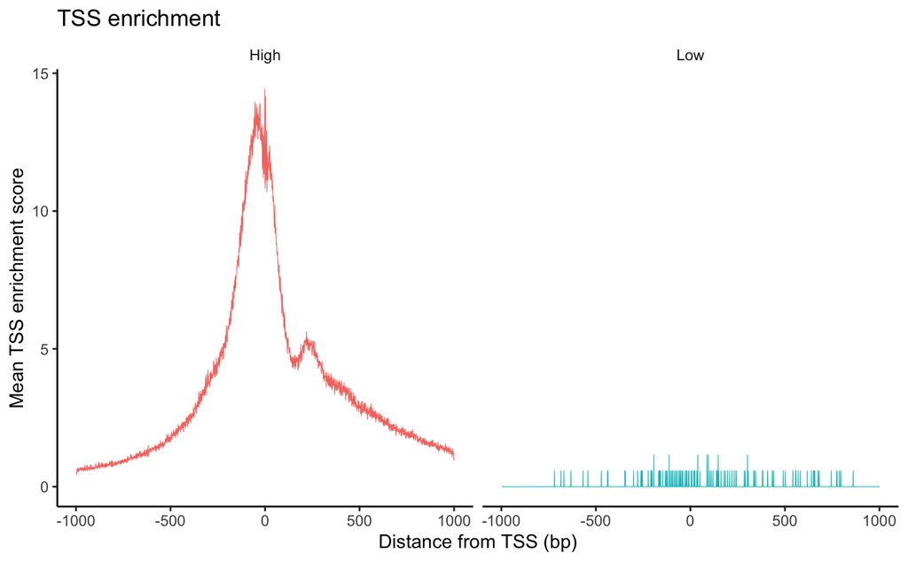

```r
pbmc$high.tss <- ifelse(pbmc$TSS.enrichment > 1.5, 'High', 'Low')
TSSPlot(pbmc, group.by = 'high.tss') + NoLegend()
```

We can also look at the fragment length periodicity for all the cells, and group by cells with high or low nucleosomal signal strength. You can see that cells that are outliers for the mononucleosomal / nucleosome-free ratio (based on the plots above) have different nucleosomal banding patterns. The remaining cells exhibit a pattern that is typical for a successful ATAC-seq experiment.

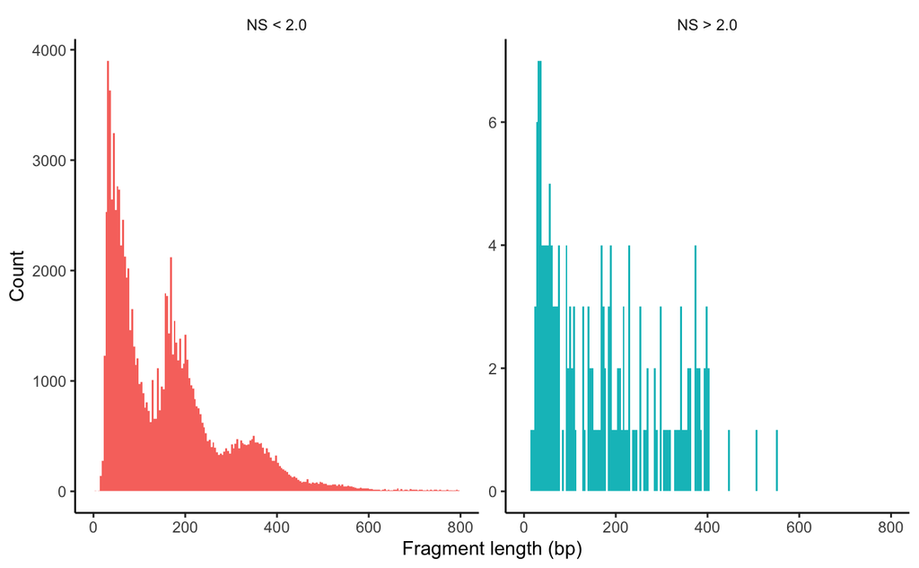

```r
pbmc$nucleosome_group <- ifelse(pbmc$nucleosome_signal > 2.0, 'NS > 2.0', 'NS < 2.0')
FragmentHistogram(object = pbmc, group.by = 'nucleosome_group')
```

- TSS enrichment scores grouped by high or low nucelosomal signal strength
- Typical TSS enrichment plot shows that nucleosome-free fragments are enriched at TSS, while mono-nucleosome fragments are depleted at TSS but enriched at flanking regions.

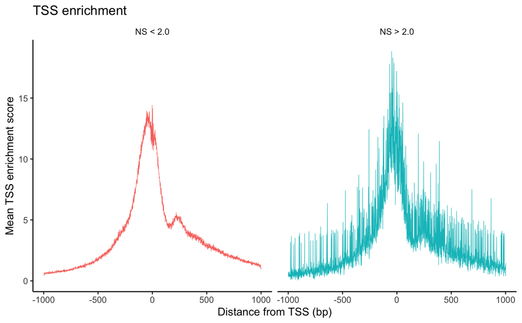

```r
TSSPlot(pbmc, group.by = 'nucleosome_group') + NoLegend()
```

```r
# add blacklist ratio and fraction of reads in peaks
#pbmc$pct_reads_in_peaks <- pbmc$peak_region_fragments / pbmc$passed_filters * 100
#pbmc$blacklist_ratio <- pbmc$blacklist_region_fragments / pbmc$peak_region_fragments
```

# 4 Counting fragments in genome blacklist regions

The ratio of reads in genomic blacklist regions, that are known to artifactually accumulate reads in genome sequencing assays, can be diagnostic of low-quality cells. We provide blacklist region coordinates for several genomes (hg19, hg38, mm9, mm10, ce10, ce11, dm3, dm6) in the Signac package for convenience. These regions were provided by the ENCODE consortium, and we encourage users to cite their paper if you use the regions in your analysis. The FractionCountsInRegion() function can be used to calculate the fraction of all counts within a given set of regions per cell. We can use this function and the blacklist regions to find the fraction of blacklist counts per cell.

```r
# not run
pbmc$blacklist_fraction <- FractionCountsInRegion(
  object = pbmc,
  assay = 'ATAC',
  regions = blacklist_hg19
)
```

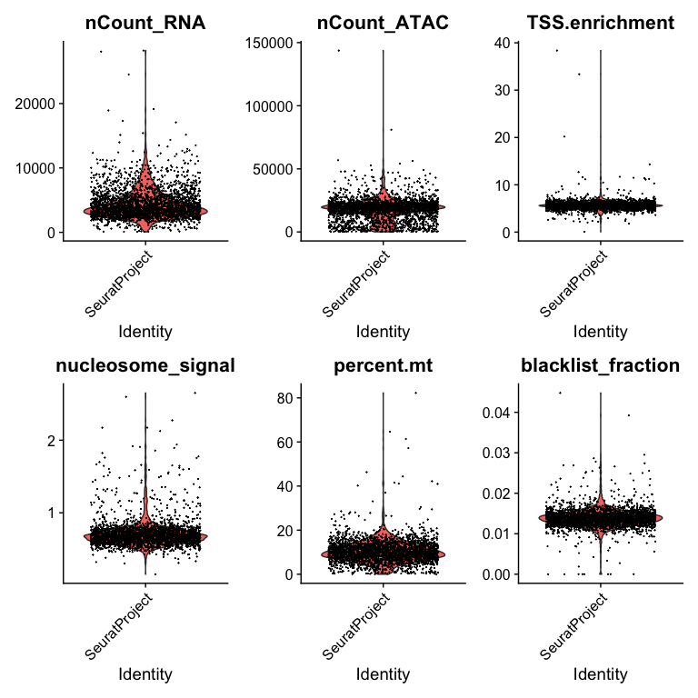

```r
VlnPlot(
  object = pbmc,
  features = c("nCount_RNA", "nCount_ATAC", "TSS.enrichment", "nucleosome_signal","percent.mt", "blacklist_fraction"),
  ncol = 3,
  pt.size = 0.02,
  log=F
)
```

- Filter out low quality cells

```r
# filter out low quality cells
pbmc <- subset(
  x = pbmc,
  subset = nCount_ATAC < 50000 &
    nCount_RNA < 12000 &
    nCount_ATAC > 500 &
    nCount_RNA > 500 &
    nucleosome_signal < 1.5 &
    TSS.enrichment > 1 &
    percent.mt <20 &
    blacklist_fraction < 0.05
)
pbmc
```

```
An object of class Seurat
134680 features across 2544 samples within 2 assays
Active assay: ATAC (98079 features, 0 variable features)
 1 other assay present: RNA
```

# 5 Peak calling

The set of peaks identified using Cellranger often merges distinct peaks that are close together. This can create a problem for certain analyses, particularly motif enrichment analysis and peak-to-gene linkage. To identify a more accurate set of peaks, we can call peaks using MACS2 with the CallPeaks() function. Here we call peaks on all cells together, but we could identify peaks for each group of cells separately by setting the group.by parameter, and this can help identify peaks specific to rare cell populations.

```r
# call peaks using MACS2
peaks <- CallPeaks(pbmc, macs2.path = "/Users/devikaagarwal/tools/2021_conda/envs/peaktools_env/bin/macs2")
```

[output not shown]

[output cut: 28 more lines]

[output not shown]

```r
# remove peaks on nonstandard chromosomes and in genomic blacklist regions
peaks <- keepStandardChromosomes(peaks, pruning.mode = "coarse")
peaks <- subsetByOverlaps(x = peaks, ranges = blacklist_hg38_unified, invert = TRUE)

# quantify counts in each peak
macs2_counts <- FeatureMatrix(
  fragments = Fragments(pbmc),
  features = peaks,
  cells = colnames(pbmc)
)
```

```
Extracting reads overlapping genomic regions
```

[output not shown]

```r
# create a new assay using the MACS2 peak set and add it to the Seurat object
pbmc[["peaks"]] <- CreateChromatinAssay(
  counts = macs2_counts,
  fragments = fragpath,
  annotation = annotation
)
```

```
Computing hash
Checking for 2544 cell barcodes
```

```r
saveRDS(pbmc, file="signac_seurat_pbmc_3k.rds")
```

# 6 Gene expression data processing

We can normalize the gene expression data using SCTransform, and reduce the dimensionality using PCA.

```r
DefaultAssay(pbmc) <- "RNA"
pbmc <- SCTransform(pbmc)
```

```
Calculating cell attributes from input UMI matrix: log_umi
Variance stabilizing transformation of count matrix of size 18925 by 2544
Model formula is y ~ log_umi
Get Negative Binomial regression parameters per gene
Using 2000 genes, 2544 cells
```

[output not shown]

[output not shown]

[output not shown]

[output not shown]

```
Found 38 outliers - those will be ignored in fitting/regularization step

Second step: Get residuals using fitted parameters for 18925 genes
```

```
Computing corrected count matrix for 18925 genes
```

```
Wall clock passed: Time difference of 35.11416 secs
Determine variable features
Place corrected count matrix in counts slot
Centering data matrix

Set default assay to SCT
```

```r
pbmc <- RunPCA(pbmc)
```

```
PC_ 1
Positive:  VCAN, PLXDC2, LYZ, SLC8A1, SAT1, ZEB2, LRMDA, DPYD, FCN1, NAMPT
       S100A9, NEAT1, TYMP, JAK2, S100A8, LYN, CD36, ARHGAP26, AOAH, LYST
       LRRK2, RBM47, ANXA1, PID1, PLCB1, PSAP, DMXL2, MARCH1, CTSS, MCTP1
Negative:  RPS27, IL32, BCL11B, LEF1, BCL2, IL7R, INPP4B, EEF1A1, BACH2, LTB
       CAMK4, RPL13A, RPL41, RPS27A, RPL13, SKAP1, RPS12, TRAC, RPS29, CD247
       TRBC1, ANK3, PRKCH, TRBC2, RPS18, RPL23A, RPL3, RPL30, THEMIS, RPS2
PC_ 2
Positive:  IL32, VCAN, CCL5, BCL11B, NKG7, CD247, GNLY, PRKCH, IL7R, INPP4B
       LEF1, DPYD, TRAC, PLCB1, ANXA1, CAMK4, PLXDC2, TRBC1, THEMIS, ARHGAP26
       GZMA, NEAT1, TC2N, TRBC2, CD3D, RORA, PDE3B, AOAH, TXK, CTSW
Negative:  BANK1, AFF3, CD74, IGHM, RALGPS2, MS4A1, CD79A, PAX5, IGKC, HLA-DRA
       FCRL1, EBF1, OSBPL10, LINC00926, BLK, CD79B, NIBAN3, HLA-DQA1, COL19A1, IGHD
       ADAM28, HLA-DRB1, CD22, AP002075.1, BCL11A, FCER2, SEL1L3, COBLL1, CCSER1, PLEKHG1
PC_ 3
Positive:  LEF1, BACH2, CAMK4, FHIT, INPP4B, IL7R, PDE3B, MAML2, BCL2, CCR7
       BCL11B, NELL2, ANK3, SERINC5, TCF7, PRKCA, TSHZ2, LTB, EEF1A1, OXNAD1
       MLLT3, AC139720.1, TRABD2A, VCAN, RASGRF2, MAL, PIK3IP1, RCAN3, SELL, LDHB
Negative:  NKG7, GNLY, CCL5, PRF1, GZMA, CST7, KLRD1, GZMH, FGFBP2, CTSW
       GZMB, CCL4, SPON2, TGFBR3, ADGRG1, FCGR3A, KLRF1, PDGFD, TRDC, A2M
       IFITM2, PYHIN1, PPP2R2B, IL2RB, CLIC3, SAMD3, C1orf21, KLRG1, SYNE1, HOPX
PC_ 4
Positive:  CST3, AIF1, IFITM3, FCGR3A, LST1, TCF7L2, CDKN1C, PSAP, HLA-DPA1, SERPINA1
       IFI30, FCER1G, ACTB, WARS, COTL1, CD74, MS4A7, SMIM25, MTSS1, HLA-DRA
       CSF1R, HLA-DRB1, TMSB4X, FTL, CFD, TYROBP, S100A4, S100A11, CTSS, HLA-DPB1
Negative:  VCAN, PLCB1, ARHGAP24, ARHGAP26, DPYD, PLXDC2, GNLY, CD36, ANXA1, ACSL1
       NKG7, DYSF, LRMDA, FNDC3B, MEGF9, PDE4D, S100A8, CCL5, AC020916.1, CSF3R
       BANK1, CREB5, SLC2A3, TMTC2, RBM47, S100A9, IGHM, RAB11FIP1, LRRK2, PRF1
PC_ 5
Positive:  PTPRS, LINC01374, PLD4, CUX2, AC023590.1, IRF8, CLEC4C, LINC00996, RUNX2, ITM2C
       ZFAT, EPHB1, GZMB, LILRA4, TCF4, UGCG, CCDC50, FAM160A1, RHEX, COL26A1
       SLC35F3, IRF7, DNASE1L3, SCN9A, LINC01478, ALOX5AP, SERPINF1, COL24A1, JCHAIN, MZB1
Negative:  BANK1, MS4A1, RALGPS2, PAX5, CD79A, FCRL1, IGHM, EBF1, LINC00926, OSBPL10
       CD79B, COL19A1, MTSS1, IGHD, BACH2, CD22, FCER2, AP002075.1, ADAM28, PLEKHG1
       FCGR3A, IFNG-AS1, TCF7L2, AC120193.1, IKZF3, SWAP70, LARGE1, LIX1-AS1, SIPA1L1, CDK14
```

```r
DefaultAssay(pbmc) <- "SCT"
pbmc <- RunUMAP(pbmc, dims = 1:30,reduction.name = "umap.rna", reduction.key = "rnaUMAP_")
```

# 7 DNA accessibility data processing

Here we process the DNA accessibility assay the same way we would process a scATAC-seq dataset, by performing latent semantic indexing (LSI).

```r
DefaultAssay(pbmc) <- "peaks"
pbmc <- FindTopFeatures(pbmc, min.cutoff = 15)
pbmc <- RunTFIDF(pbmc)
```

```
Performing TF-IDF normalization
```

```r
pbmc <- RunSVD(pbmc)
```

```
Running SVD
Scaling cell embeddings
```

The first LSI component often captures sequencing depth (technical variation) rather than biological variation. If this is the case, the component should be removed from downstream analysis. We can assess the correlation between each LSI component and sequencing depth using the DepthCor() function:

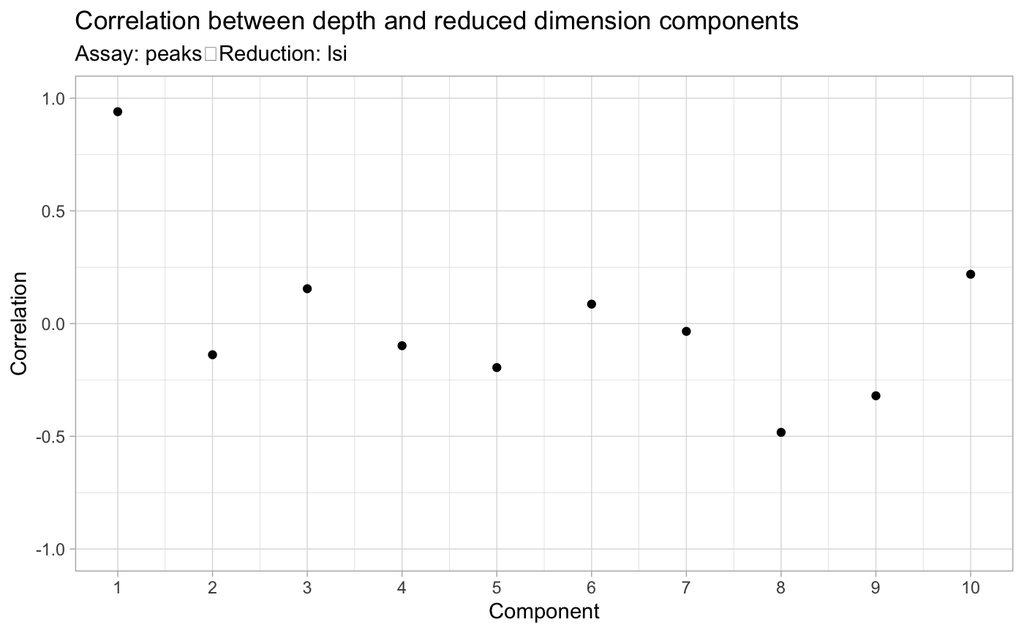

```r
DepthCor(pbmc)
```

```r
pbmc <- RunUMAP(pbmc, reduction = "lsi", dims = 2:50, reduction.name = "umap.peaks", reduction.key = "peaksUMAP_")
```

Now we plot the results from both modalities. Cells have been previously annotated based on transcriptomic state. We will predict annotations for the scATAC-seq cells.

```r
p1 <- DimPlot(pbmc, label = FALSE, reduction = "umap.rna") + NoLegend() + ggtitle("RNA")
```

[output not shown]

```r
p2 <- DimPlot(pbmc, label = FALSE, reduction = "umap.peaks") + NoLegend() + ggtitle("PEAKS")
```

[output not shown]

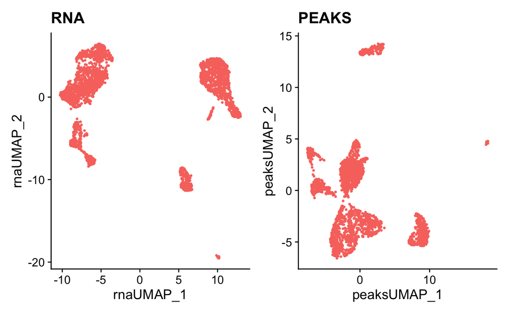

```r
p1 + p2
```

```r
saveRDS(pbmc, file="signac_seurat_pbmc_3k.rds")
```

A WNN graph for for Joint ATAC + RNAseq visualization and clustering

```r
pbmc <- FindMultiModalNeighbors(pbmc, reduction.list = list("pca", "lsi"), dims.list = list(1:50, 2:40))
```

```
Calculating cell-specific modality weights
Finding 20 nearest neighbors for each modality.
```

```
  |                                                  | 0 % ~calculating
  |+++++++++++++++++++++++++                         | 50% ~01s
  |++++++++++++++++++++++++++++++++++++++++++++++++++| 100% elapsed=02s
```

```
Calculating kernel bandwidths
```

```
  |                                                  | 0 % ~calculating
  |+++++++++++++++++++++++++                         | 50% ~00s
  |++++++++++++++++++++++++++++++++++++++++++++++++++| 100% elapsed=00s
```

```
Finding multimodal neighbors
```

```
  |                                                  | 0 % ~calculating
  |+++++++++++++++++++++++++                         | 50% ~03s
  |++++++++++++++++++++++++++++++++++++++++++++++++++| 100% elapsed=06s

  |                                                  | 0 % ~calculating
  |+++++++++++++++++++++++++                         | 50% ~00s
  |++++++++++++++++++++++++++++++++++++++++++++++++++| 100% elapsed=00s
```

```
Constructing multimodal KNN graph
Constructing multimodal SNN graph
```

```r
pbmc <- RunUMAP(pbmc, nn.name = "weighted.nn", reduction.name = "wnn.umap", reduction.key = "wnnUMAP_")
pbmc <- FindClusters(pbmc, graph.name = "wsnn", algorithm = 3, verbose = FALSE)
```

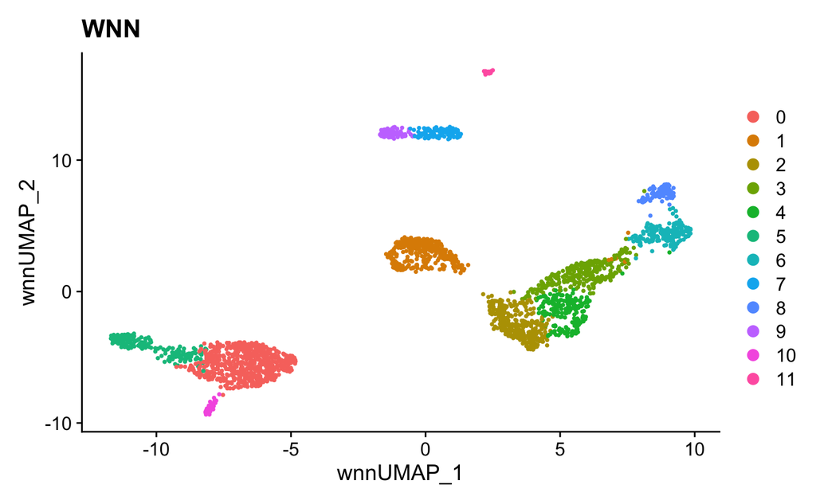

```r
DimPlot(pbmc, reduction = "wnn.umap", label = T, label.size = 2.5, repel = TRUE) + ggtitle("WNN")
```

Annotate cell types using multi-modal PBMC reference dataset

```r
library(SeuratDisk)

# load PBMC reference
reference <- LoadH5Seurat("./pbmc_multimodal.h5seurat")
```

[output not shown]

```r
p1<- DimPlot(object = reference, reduction = "wnn.umap", group.by = "celltype.l1", label = TRUE, label.size = 3, repel = TRUE) + NoLegend()
```

```
Rasterizing points since number of points exceeds 100,000.
To disable this behavior set `raster=FALSE`
```

```r
p2<- DimPlot(object = reference, reduction = "wnn.umap", group.by = "celltype.l2", label = TRUE, label.size = 3, repel = TRUE) + NoLegend()
```

```
Rasterizing points since number of points exceeds 100,000.
To disable this behavior set `raster=FALSE`
```

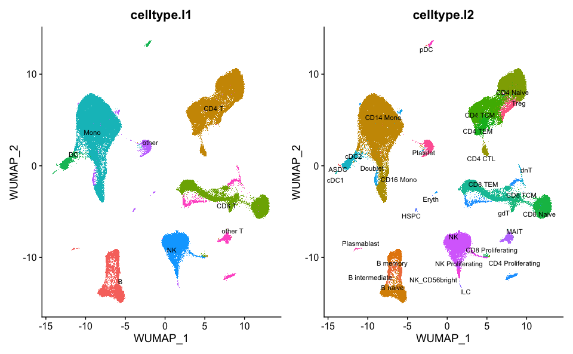

```r
p1 + p2
```

```r
DefaultAssay(pbmc) <- "RNA"

# transfer cell type labels from reference to query
transfer_anchors <- FindTransferAnchors(
  reference = reference,
  query = pbmc,
  normalization.method = "LogNormalize",
  reference.reduction = "spca",
  recompute.residuals = FALSE,
  dims = 1:50
)
```

```
Projecting cell embeddings
Finding neighborhoods
```

```
Finding anchors
    Found 2055 anchors
Filtering anchors
```

```
    Retained 1373 anchors
```

```r
predictions <- TransferData(
  anchorset = transfer_anchors,
  reference = reference,
  refdata = list(
    celltype.l1 = "celltype.l1",
    celltype.l2 = "celltype.l2",
    predicted_ADT = "ADT"),
  weight.reduction = pbmc[['pca']],
  dims = 1:50
)
```

```
Finding integration vectors
Finding integration vector weights
```

```
Predicting cell labels
Predicting cell labels
Transfering 228 features onto reference data
```

Annotated celltype visualisation

Celltype L1

```r
pbmc <- AddMetaData(
  object = pbmc,
  metadata = predictions$celltype.l1
)

# set the cell identities to the cell type predictions
Idents(pbmc) <- "predicted.id"
```

Celltype L1

```r
p1 <- DimPlot(pbmc, reduction = "umap.rna", group.by = "predicted.id", label = TRUE, label.size = 3.0, repel = TRUE) + ggtitle("RNA")
```

[output not shown]

```r
p2 <- DimPlot(pbmc, reduction = "umap.peaks", group.by = "predicted.id", label = TRUE, label.size = 3.0, repel = TRUE) + ggtitle("ATAC")
```

[output not shown]

```r
p3 <- DimPlot(pbmc, reduction = "wnn.umap", group.by = "predicted.id", label = TRUE, label.size = 3.0, repel = TRUE) + ggtitle("WNN")
```

[output not shown]

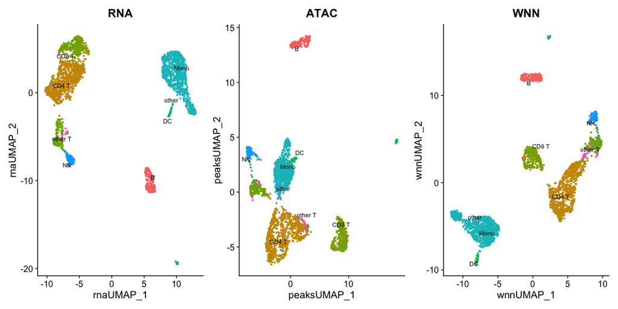

```r
p1 + p2 + p3 & NoLegend() & theme(plot.title = element_text(hjust = 0.5))
```

```r
pbmc <- AddMetaData(
  object = pbmc,
  metadata = predictions$celltype.l2
)

# set the cell identities to the cell type predictions
Idents(pbmc) <- "predicted.id"

# set a reasonable order for cell types to be displayed when plotting
levels(pbmc) <- c("CD4 Naive", "CD4 TCM", "CD4 CTL", "CD4 TEM", "CD4 Proliferating",
                  "CD8 Naive", "dnT",
                 "CD8 TEM", "CD8 TCM", "CD8 Proliferating", "MAIT", "NK", "NK_CD56bright",
                 "NK Proliferating", "gdT",
                 "Treg", "B naive", "B intermediate", "B memory", "Plasmablast",
                 "CD14 Mono", "CD16 Mono",
                 "cDC1", "cDC2", "pDC", "HSPC", "Eryth", "ASDC", "ILC", "Platelet")
```

Celltype L2

```r
p1 <- DimPlot(pbmc, reduction = "umap.rna", group.by = "predicted.id", label = TRUE, label.size = 3.0, repel = TRUE) + ggtitle("RNA")
```

[output not shown]

```r
p2 <- DimPlot(pbmc, reduction = "umap.peaks", group.by = "predicted.id", label = TRUE, label.size = 3.0, repel = TRUE) + ggtitle("ATAC")
```

[output not shown]

```r
p3 <- DimPlot(pbmc, reduction = "wnn.umap", group.by = "predicted.id", label = TRUE, label.size = 3.0, repel = TRUE) + ggtitle("WNN")
```

[output not shown]

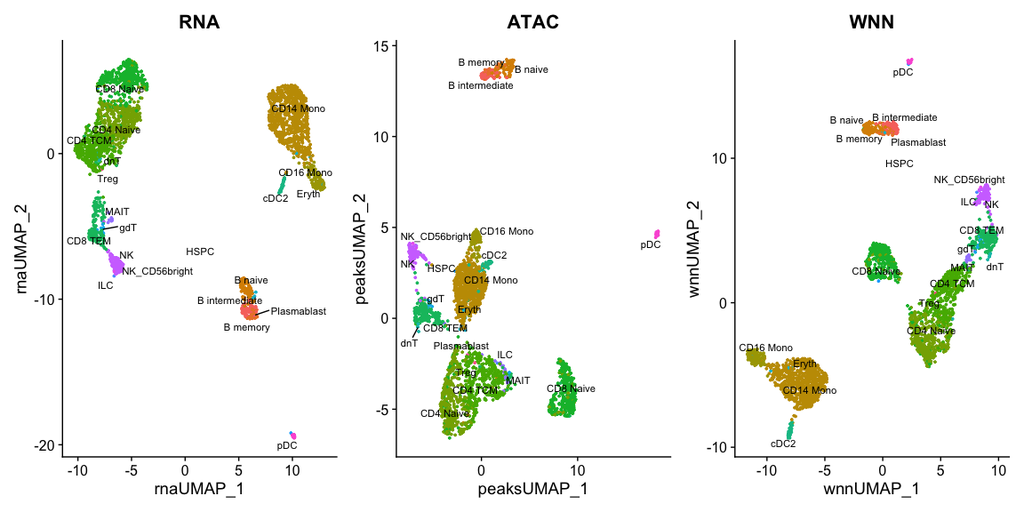

```r
p1 + p2 + p3 & NoLegend() & theme(plot.title = element_text(hjust = 0.5))
```

Linking peaks to genes For each gene, we can find the set of peaks that may regulate the gene by by computing the correlation between gene expression and accessibility at nearby peaks, and correcting for bias due to GC content, overall accessibility, and peak size. See the Signac paper for a full description of the method we use to link peaks to genes.

Running this step on the whole genome can be time consuming, so here we demonstrate peak-gene links for a subset of genes as an example. The same function can be used to find links for all genes by omitting the genes.use parameter:

```r
DefaultAssay(pbmc) <- "peaks"

# first compute the GC content for each peak
pbmc <- RegionStats(pbmc, genome = BSgenome.Hsapiens.UCSC.hg38)

# link peaks to genes
pbmc <- LinkPeaks(
  object = pbmc,
  peak.assay = "peaks",
  expression.assay = "SCT",
  genes.use = c('CD8A','CD4','CD8B')
)
```

```
Testing 3 genes and 89978 peaks
```

```
  |                                                  | 0 % ~calculating
  |+++++++++++++++++                                 | 33% ~10s
  |++++++++++++++++++++++++++++++++++                | 67% ~03s
  |++++++++++++++++++++++++++++++++++++++++++++++++++| 100% elapsed=09s
```

For example, the ATAC-seq data assists in the separation of CD4 and CD8 T cell states. This is due to the presence of multiple loci that exhibit differential accessibility between different T cell subtypes. For example, we can visualize ‘pseudobulk’ tracks of the CD8A and CD4 locus alongside violin plots of gene expression levels, using tools in the Signac visualization vignette.

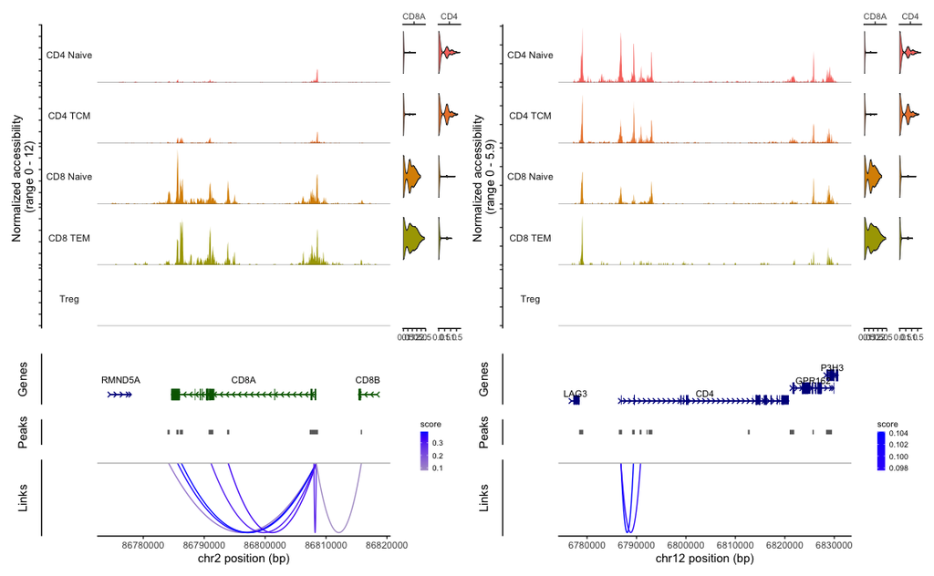

```r
## to make the visualization easier, subset T cell clusters
celltype.names <- levels(pbmc)
tcell.names <- grep("CD4|CD8|Treg", celltype.names,value = TRUE)
tcells <- subset(pbmc, idents = tcell.names)
CoveragePlot(object = pbmc, region = c('CD8A','CD4'), features = c('CD8A','CD4'), assay = 'peaks', expression.assay = 'SCT', peaks = T,
            extend.upstream = 10000, extend.downstream = 10000, links = T, idents = tcell.names)
```

# 8 Calling celltype specific peaks

- To call peaks on each annotated cell type, we can use the group.by argument:
- predicted.id : celltype L2

```r
DefaultAssay(pbmc) <- "ATAC"
peaks_celltypel2 <- CallPeaks(pbmc, macs2.path = "/Users/devikaagarwal/tools/2021_conda/envs/peaktools_env/bin/macs2", group.by = "predicted.id")
```

Coverage plot comparing CD4 and CD8 locus peaks and expression, with celltype specific peaks

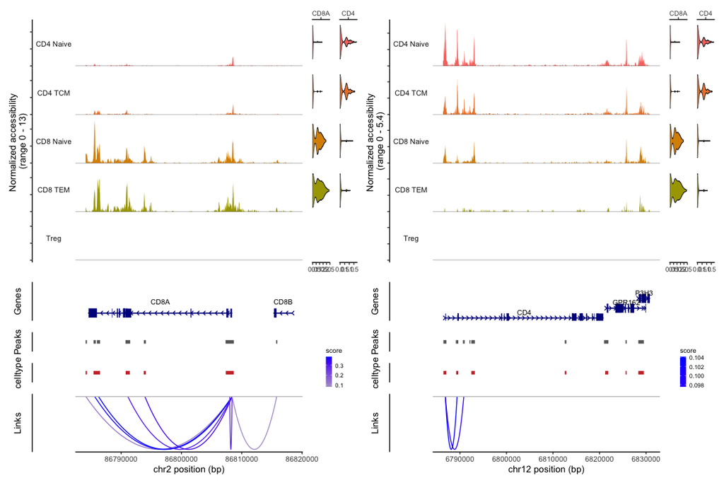

```r
## to make the visualization easier, subset T cell clusters
celltype.names <- levels(pbmc)
tcell.names <- grep("CD4|CD8|Treg", celltype.names,value = TRUE)
tcells <- subset(pbmc, idents = tcell.names)
CoveragePlot(object = pbmc, region = c('CD8A','CD4'), features = c('CD8A','CD4'), assay = 'peaks', expression.assay = 'SCT', peaks = T,
            extend.upstream = 500, extend.downstream = 10000, links = T, idents = tcell.names, ranges = peaks_celltypel2, ranges.title = "celltype")
```

```r
saveRDS(pbmc, file="./signac_seurat_pbmc_3k.rds")
```

```r
saveRDS(peaks_celltypel2, file="./signac_seurat_macs2_celltype_peaks_pbmc_3k.rds")
```

```r
pbmc <- readRDS(file = "./signac_seurat_pbmc_3k.rds")
```

# 9 Modality specific celltype weights

```r
p1 <- VlnPlot(pbmc, features = "SCT.weight", group.by = 'predicted.id', sort = TRUE, pt.size = 0.05) +
  NoLegend() + ggtitle("RNA modality weights")
```

[output not shown]

```r
p2 <- VlnPlot(pbmc, features = "peaks.weight", group.by = 'predicted.id', sort = TRUE, pt.size = 0.05) +
  NoLegend() + ggtitle("MACS2 peaks weights")
```

[output not shown]

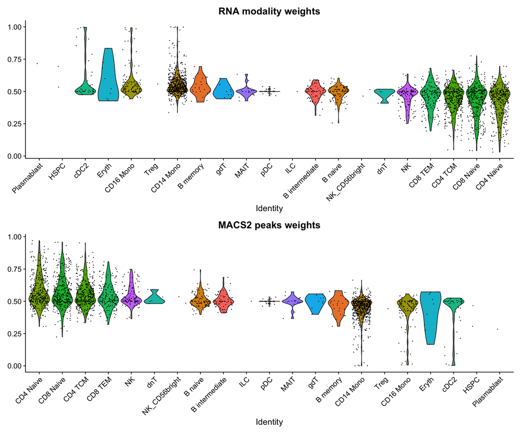

```r
p1 + p2
```